# Application Exercise 15 - Communicate your results

Lars Schöbitz

Another Author

# Exam Practice

## Task 1.0 (0.5)

1. Render the document and fix any errors.

```r
library(tidyverse)
```

## Task 1.1 (1)

**Fill in the blanks**

1. Use the `read_csv` function to import the following CSV file from the “data/raw_data/” directory:
- `msw-generation-and-composition-by-income.csv`, and assign to the object `waste_data`
2. In the YAML header, next to `eval:` change the value from `false` to `true`

```r
waste_data <- read_csv("data/raw_data/msw-generation-and-composition-by-income.csv")
```

## Task 1.2 (2)

**Write the code yourself**

1. Start with the `waste_data` object and use a function of your choice to create a subset that removes NAs from the variable that stores values for municipal solid waste generation.
2. Use the pipe operator to add another line of code which uses the `mutate()` function to convert the `income_cat` variable from a variable of type character to a variable of type factor. Define the factor levels yourself.
3. Store the result as a new object in your environment with the name `waste_generation_tidy`

```r
income_cat_levels <- c("low income", "lower-middle income", "upper-middle income", "high income")

waste_generation_tidy <- waste_data %>%
  drop_na(msw_capita_kg_year) %>%
  mutate(income_cat = factor(income_cat, levels = income_cat_levels))
```

## Task 1.3 (6)

**Write the code yourself**

1. Use functions taught during the course to answer the following question for the `waste_generation_tidy` data object:

What is the minimum, mean, standard deviation, and maximum of the municipal solid waste generation grouped by income? Also add the count for the number of countries in each income category.

2. Store the result as a new object in your environment with the name `waste_generation_tbl`.

```r
waste_generation_tbl <- waste_generation_tidy %>%
  group_by(income_cat) %>%
  summarise(
    count = n(),
    min = min(msw_capita_kg_year),
    mean = mean(msw_capita_kg_year),
    sd = sd(msw_capita_kg_year),
    max = max(msw_capita_kg_year)
  )
```

## Task 1.4 - Hand-in (0.5)

1. Render the document and fix any errors.

Last complete render: 2022-06-01 21:36:40 at timezone Europe/Zurich.

# Introduction

## What a Waste!

What a Waste is a global project to aggregate data on solid waste management from around the world (World 2019).

# Results & Discussion

## Waste generation - Summary

- Data was available for 215 countries
- High income countries have an average waste generation of 612 kg/cap/year
- Low income countries have an average waste generation of 163 kg/cap/year
- Results for all income categories are shown in Table 1 and Figure 1

## Waste generation - Table

Table 1: Waste generation by income category.

| income category | count | min | mean | sd | max |
| --- | --- | --- | --- | --- | --- |
| low income | 33 | 61 | 163 | 65 | 368 |
| lower-middle income | 47 | 37 | 216 | 191 | 1120 |
| upper-middle income | 56 | 93 | 305 | 103 | 530 |
| high income | 79 | 161 | 612 | 245 | 1385 |

## Waste generation - Plot

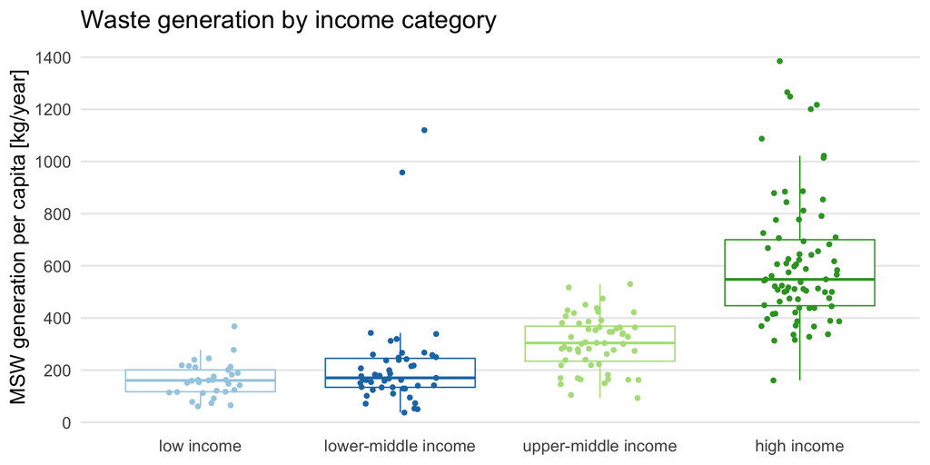

Figure 1: Waste generation by income category.

# References

World, Bank. 2019. “What a Waste Global Database | Data Catalog.” https://datacatalog.worldbank.org/search/dataset/0039597.